# Examen parcial 1 - Métodos Cuantitativos en Ecología

Paula Vela

23 de mayo de 2023

```r
library(agricolae)
sitios <-c("Parque Itchimbia", "Parque Guanguiltagua", "Parque La Corolina")
r <- 3
seed = 100
crd1 <-design.crd(trt= sitios,
                  r = r,
                  serie=2,
                  seed = seed,
                  kind = "Super-Duper",
                  randomization = TRUE)
crd_re <- crd1$book
crd_re$etapas<- NaN
crd_re$coverturavegetal<- NaN
crd_re$diversidad<-NaN
crd_re$Abundacia<-NaN
crd_re$tiposdesielos<-NaN
# write to hard disk
write.csv(crd_re,"rarespecies.csv", row.names=FALSE, sep=";")
# file.show("crd.txt")
```

El diseño de la muestra que se ejucutó tenuendo en cuenta 3 pafques con alta cobertura vegetal de la ciudad de Quito, por lo cual se podría encontrar alta diversidad de especies y de esta manera encontrar especies raras. Además, se tuvo en cuenta la abundancia de las mismas y las etapas.

## 0.1 Variables

Las variables independientes es cobertura vegetal, diverisidad de especies y el tipo de suelo a que son las que nos ayudan a determinar la etapa de ciclo de vida de las especies y la abundancia de las mismas en estos lugares. Por lo que, etapa, abundancia y diversidad son variables dependientes.

## 0.2 Gráfica e hipótesis

La cobertura vegetal de un sitio y el tipo del suelo ayudan a la crecimiento de plantas, incluyendo las especies raras (diversidad), por lo que dependiendo de estos facoteres se puede determinar la abundancia de las mismas

Gráfica:

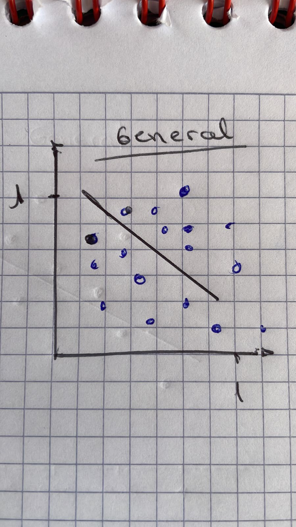

En esta parte debe aplicar las regresiones lineal, linearizada y generalizada sobre la presencia de ácaros en musgos. Una de las especies analizadas es *Galumma sp.* cuya abundancia presencia y proporción es posiblemente afectada por las siguiente cinco variables ambientales como densidad de sustrato, el tipo de sustrato, el contenido de agua, si se tiene o no arbustos en la cercanía y la topografía del suelo. Utilice la data `mites.csv` y responda los siguientes items.

- ¿Cuál es el efecto de las variables ambientales en la i) abundancia de ii) abundancia y iii) proporción de la especie *Galumma sp.*?

Para responder esta pregunta debe generar las hipótesis y probar las hipótesis (código y explicación), asimismo visualizar con etiquetas adecuadas. Considere realizar lo siguiente:

- Realizar un análisis exploratorio.
- Realizar regresiones lineales de cada variable de respuesta y variables efectoras, univariable o multivariable. Verifique los supuestos de la regresión.
- Realizar regresiones linearizadas de cada variable de respuesta y variables efectoras, univariable o multivariable.
- Realizar regresiones lineales generalizadas de cada variable de respuesta y variables efectoras, univariable o multivariable.
- Comparar de la bondad de las regresiones.